# Reproducible Research: Peer Assessment 1

Joy Zylinski

2018-03-11

## Loading and preprocessing the data

Prerequisite: first confirm that the working directory is set to the forked and cloned Github repository on your local machine. You will also need the following packages installed: dplyr, tidyverse, ggplot2

```r
zipF <- "./activity.zip"
unzip(zipF)
data <- read.csv("./activity.csv")
```

```r
library(dplyr)
library(tidyverse)
```

```r
library(ggplot2)
```

## What is mean total number of steps taken per day?

```r
byDate <- data %>% filter(!is.na(data$steps)) %>% group_by(date) %>% summarize(steps = sum(steps))
```

```r
meanSteps <- mean(byDate$steps)
```

```r
medianSteps <- median(byDate$steps)
```

### Make a histogram of the total number of steps taken each day.

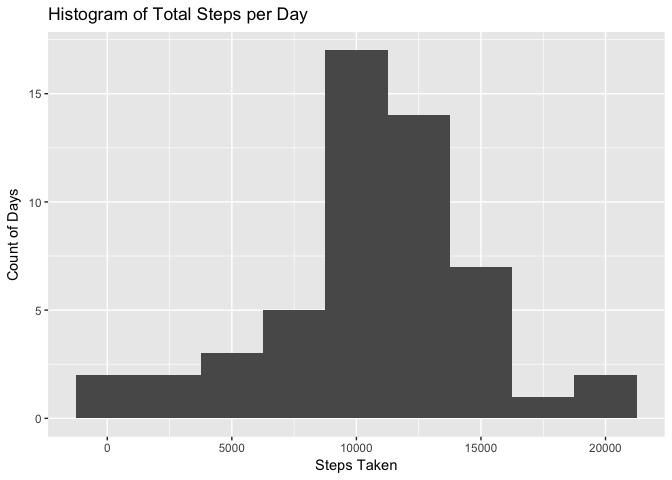

```r
g <- ggplot(byDate,aes(steps))
g + geom_histogram(binwidth = 2500) + labs(title = "Histogram of Total Steps per Day", y = "Count of Days", x = "Steps Taken")
```

## What is the average daily activity pattern?

### Make a time series plot (i.e. 𝚝𝚢𝚙𝚎 = “𝚕”) of the 5-minute interval (x-axis) and the average number of steps taken, averaged across all days (y-axis)

```r
byInterval <- data %>% filter(!is.na(data$steps)) %>% group_by(interval) %>% summarize(steps = mean(steps))
```

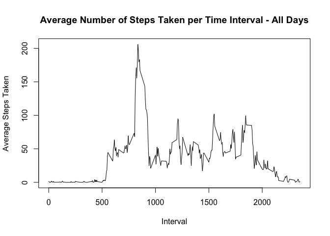

```r
plot(byInterval$interval, byInterval$steps, type = "l", xlab = "Interval", ylab = "Average Steps Taken", main = "Average Number of Steps Taken per Time Interval - All Days")
```

### Which 5-minute interval, on average across all the days in the dataset, contains the maximum number of steps?

```r
byInterval %>% slice(steps %>% which.max)
```

```
## # A tibble: 1 x 2
##   interval steps
##      <int> <dbl>
## 1      835   206
```

## Imputing missing values

### Calculate and report the total number of missing values in the dataset (i.e. the total number of rows with 𝙽𝙰s)

```r
NArows <- sum(is.na(data$steps))
```

There are 2304 rows in the data set with NAs. To impute the missing values, we shall use the average across all days for the particular interval for which the value is missing.

```r
impData <- data
impData$steps[is.na(impData$steps)] <- byInterval$steps[match(impData$interval,byInterval$interval)][which(is.na(impData$steps))]
```